# Histogramas

ASR

24/5/2021

## Histogramas

Barras pegadas unas a las otras, están unidos los datos y no hay saltos por eso se juntan las barras. A mayor altura maypr frecuencia. La altura es la necesaria para que el área de la barra sea igual a la frecuencia absoluta de la misma. Pueden ser: - Histograma de frecuencias absolutas - Histograma de frecuencias relativas - Histograma de frecuencias acumuladas

Parametros funcion hist() - x - breaks - freq (relativas o no) - right - include.lowest - Parametros de plot (Con plot = FALSE no dibuja pero genera los datos)

Datos que devuelve como tabla en R: - breaks - mids (Marcas de clase) - counts (Freq. absolutas) - density (Densidades de los intervalos - altura en el caso de freq relativa. Freq.Relativa/A)

Función de histograma frecuencias absolutas:

```r
histAbs = function (x,L) {
  h = hist(x,breaks=L,freq=FALSE,xaxt="n",yaxt="n",col="lightgray",main="Histograma de frecuencias absolutas",xlab="Intervalos y marcas de clase",ylab="Frecuencias absolutas")
  axis(1,at=L)
  text(h$mids,h$density/2,labels=h$counts,col="purple")
}
```

Función de histograma frecuencias absolutas acumuladas:

```r
histAbsCum = function(x,L) {
  h = hist(x, breaks=L, right=FALSE, plot = FALSE)
  h$density = cumsum(h$density)
  plot(h,freq=FALSE,xaxt="n",yaxt="n",col="lightgray", main="Histograma de frecuencias\nabsolutas acumuladas",xlab="Intervalos",ylab="Frec. absolutas acumuladas")
  axis(1,at=L)
  text(h$mids,h$density/2,labels=cumsum(h$counts),col="purple")
}
```

Nota: Usar rug y jitter para dar visibilidad de los datos.

### Histograma de frecuencias relativas

Función de histograma frecuencias relativas: Se suele representar con la curva de densidad.

```r
histRel = function(x,L) {
  h = hist(x,breaks=L,right=FALSE,plot=FALSE)
  t = round(1.1*max(max(density(x)[[2]]),h$density),2)
  plot(h,freq=FALSE,col="lightgray",main="Histograma de frec.relativas\ny curva de densidad estimada",xaxt="n",ylim=c(0,t),xlab="Intervalos",ylab="Densidades")
  axis(1,at=L)
  text(h$mids,h$density/2,labels=round(h$counts/length(x),2),col="blue")
  lines(density(x),col="purple",lwd=2)
}
```

Función de histograma frecuencias relativas acumuladas: Se suele representar con la función de distribución.

```r
histRelCum = function(x,L) {
  h = hist(x,breaks=L,right=FALSE,plot=FALSE)
  h$density = cumsum(h$counts)/length(x)
  plot(h,freq=FALSE,col="lightgray",main="Histograma de frec.rel. acumuladas\ny curva de distribución estimada",xaxt="n",xlab="Intervalos",ylab="Densidades")
  axis(1,at=L)
  text(h$mids,h$density/2,labels=round(h$density,2),col="blue")
  dens.x = density(x)
  dens.x$y = cumsum(dens.x$y)*(dens.x$x[2]-dens.x$x[1])
  lines(dens.x,col="purple",lwd=2)
}
```

### Ejemplo con los cangrejos

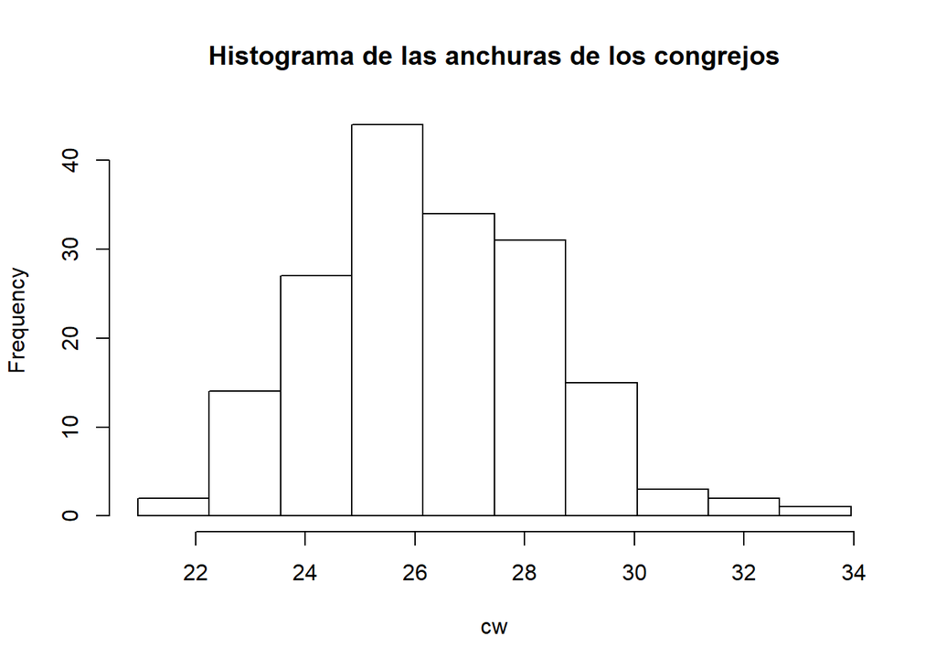

```r
crabs = read.table("../data/datacrab.txt", header=TRUE)
cw = crabs$width
n = length(cw)
A = 1.3
As = 3.5*sd(cw)*n^(-1/3) # Scott - scott(cw)
k3 = ceiling(diff(range(cw))/As)
L1 = min(cw)-1/2*0.1
L = L1 + A*(0:k3)
h = hist(cw,breaks=L, right=FALSE,main="Histograma de las anchuras de los congrejos")
```

```r
h
```

```
## $breaks
##  [1] 20.95 22.25 23.55 24.85 26.15 27.45 28.75 30.05 31.35 32.65 33.95
##
## $counts
##  [1]  2 14 27 44 34 31 15  3  2  1
##
## $density
##  [1] 0.008892841 0.062249889 0.120053357 0.195642508 0.151178301 0.137839040
##  [7] 0.066696309 0.013339262 0.008892841 0.004446421
##
## $mids
##  [1] 21.6 22.9 24.2 25.5 26.8 28.1 29.4 30.7 32.0 33.3
##
## $xname
## [1] "cw"
##
## $equidist
## [1] TRUE
##
## attr(,"class")
## [1] "histogram"
```

Usando las funciones creadas. Frecuencias absoludas

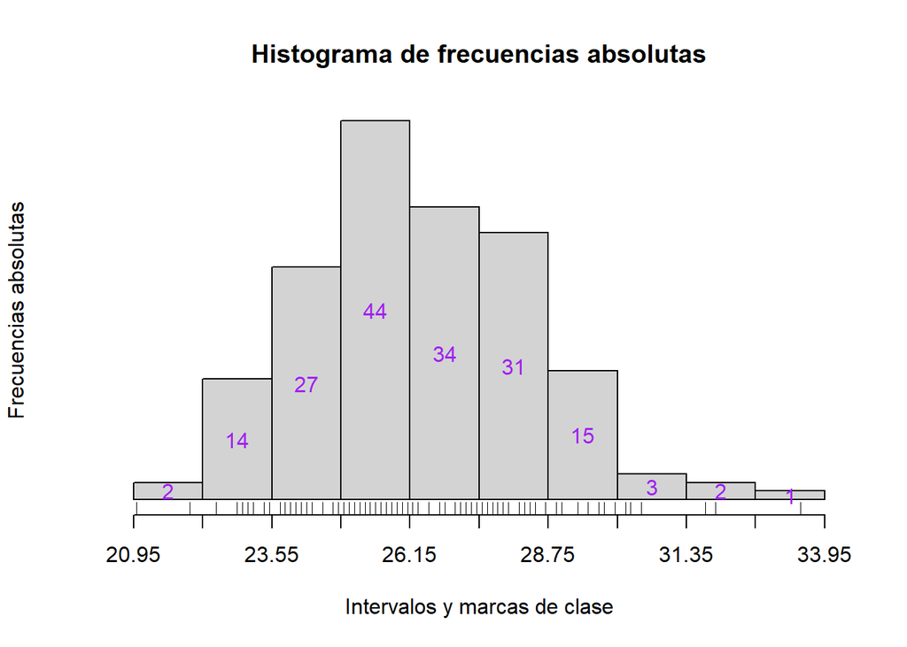

```r
histAbs(cw,L)
rug(cw)
```

Frecuencias absolutas acumuladas:

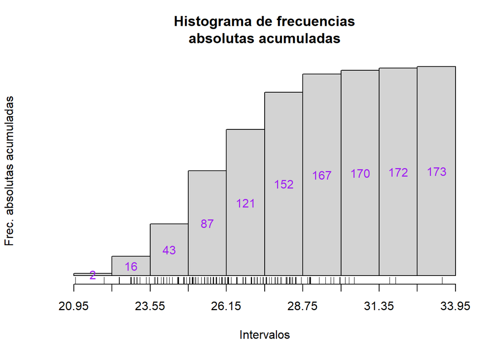

```r
histAbsCum(cw,L)
rug(jitter(cw))
```

Frecuencias relativas

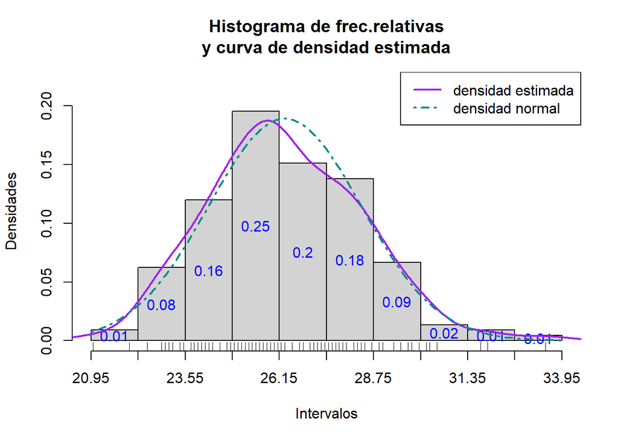

```r
histRel(cw,L)
rug(cw)
curve(dnorm(x,mean(cw),sd(cw)),col="cyan4",lty=4,lwd=2,add=TRUE)
legend("topright",lwd=c(2,2),lty=c(1,4),col=c("purple","cyan4"),legend=c("densidad estimada","densidad normal"))
```

Frecuencias relativas acumuladas:

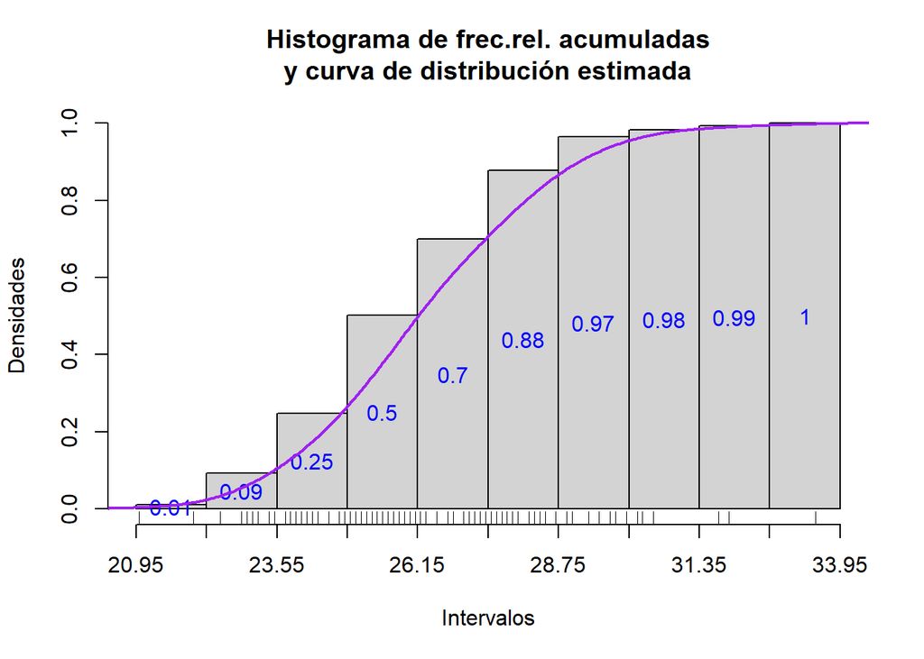

```r
histRelCum(cw,L)
rug(cw)
```